# ChIP protocol

## Preparation of mycelium

Culture - Inoculate 6 Roux bottles of 100 ml of medium with a fresh mycelium (grown 1 or 2 days on M2 medium at 27°C). - Incubate 62 hours in the dark at 27°C.

Fixation - Filter the mycelium on gauze, rinse once with PBS at room temperature. - Fix in 100ml of PBS 1X + 2.5 ml Formaldehyde 37%, shake 15 min at 27°C. *Careful: Formaldehyde is toxic, work with appropriate safety equipements (gloves, chemical hood)* - Stop with 2.5 ml of Glycine 2.5 M (shake for 5 min).

Grinding and storage (In cold room) - Filter the mycelium (*the flow-through needs to be discarded in appropriate liquid trash bin*) - Wash twice with cold PBS - Dry on wattman paper (do not hesitate to press the mycelium) - Grind with liquid nitrogen with mortar and pestle. *Careful: Use appropriate safety equipments* - Weight and store at -80°C in 50 mL Falcon tubes (transport in liquid nitrogen). - In order to prepare ready-to-use aliquots : Weigh approximately 200 mg of mycelium (cool the spatula in liquid nitrogen before each sample, no more than 2 samples after removal of the mycelium from liquid nitrogen)

### Day 1

#### Lysis and chromatin digestion

- Label the tubes with your name / pair number / IP or other instruction the teachers will give.
- In the ice: Resuspend the mycelium with 1 mL of Lysis buffer (+proteinase inhibitor + CaCl2)
- Mix well at least 10 times going back and forth with the P1000 and vortex. Make sure to resuspend well the mycelium. Then leave 10 min on ice, vortex again.
- Add **5μl of Micrococcale Nuclease** and incubate **35 min at 37°C** (while continuously shaking if possible, otherwise in a waterbath) (Include a control without MNase to check digestion). If using a waterbath, gently mix the tubes every 2 min to resuspend the mycelium.
- Stop the reaction with **30 μl of EGTA** pH 8 0.5 M , incubate 5 min on ice.
- Centrifuge 3-5 min at 4°C at top speed,
- Recover the supernatant (= soluble chromatin),
- Repeat the centrifugation to remove as much as possible the unsolubilized genomic material.
- Quantify the 2µL of your chromatin (with QuBit, following the QuBit kit protocol). You may need to dilute an aliquot of the chromatin beforehand.

(Possibility of storing -80 ° C at this stage, but for the ChIP it is better to avoid the thawing steps).

#### Checking of chromatin fragmentation (nucleosomal digestion pattern)

- Save a 150µL aliquot of Micrococcale digested chromatin in a fresh tube, then add:
  - RNAse A (20mg/ml) 10 μl, 60 min at 37°C
  - Proteinase K (20mg/ml) 10 μl, 120 min at 65°C
  - SDS to 0.5%
  - Incubate at 65°C over night to reverse the crosslink

### Day 2

#### Phenol extraction of the DNA

To the tube kept over-night at 65°C,

- Adjust the volume to 300 µl with H2O
- Add 300μl phenol-chloroform (**Carefull! Phenol and chloroform must be used under the fume hood!**)
- mix or vortex
- centrifuge 3 min (top speed, room temperature)
- recover the aqueous phase in a fresh tube
- Add 300 μl chloroform to the aqueous phase
- mix or vortex
- centrifuge 3 min (top speed, room temperature)
- recover the aqueous phase in a fresh tube

#### Ethanol precipitation:

- Add 1/100th of glycogen
- Add 1/10th Sodium Acetate 3 M
- Add 2.5 volume of Ethanol 100% and mix well
- Centrifuge 15 min 16000g, 4°C, carefully remove the supernatant without aspirating the pelet.
- Add 500 μl cold ethanol 70%
- Centrifuge 5 min 16000g, 4°C, carefully remove the supernatant without aspirating the pelet.
- Air dry for 10-20 min
- Resuspend in 20 μl H2O
- Add 4μl of loading buffer
- Load everything on a 1.5% agarose gel. Run 25-30 min at 100V.

It should looks like this:

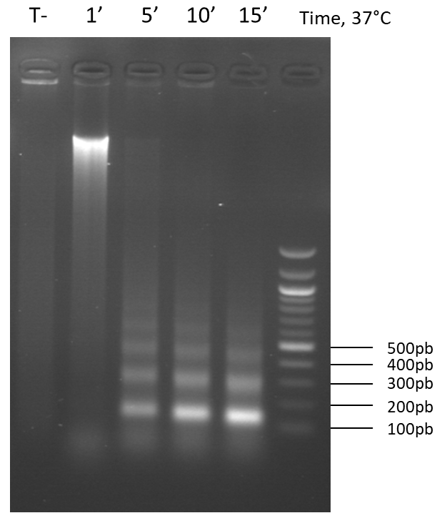

## ChIP:

Wash **50 µL** of magnetic beads per IP, as instructed here: - 30 µl will be used immediatly for the pre-clearing - 20 µl will be used the next day - **the washed beads must be stored at 4°C**

Dilution the chromatin :

- If needed, thaw the chromatin on ice.
- Seed 5 µg of chromatin in a **DNA LoBind tube**. Adjust the volume to 1.1 ml with cold Lysis buffer + protease inhibitor. Keep the tube on ice.

**Prepare as many tubes as necessary for the different IPs and controls you will need**

In the cold room:

- Pre-clearing: Add **30 μl of washed magnetic beads** to the chromatin. Incubate between 1 hour and 4 hours at 4°C on a rotating wheel.
- Place the tubes on a magnetic rack for 2-3 min and recover the supernatant in a clean DNA LoBind tube. Keep the tube on ice.
- Save 100 μl (= Input) to a new tube and freeze it at -20°C or -80°C.
- Add the appropriate amount of antibody (see here) to the rest (1 ml). Incubate over night at 4°C on a rotating wheel.

**Caution**: 1 Tube (5μg) = 1 Precipitation with 1 antibody. Prepare 1 tube for each replicate of each antibody.

*The tubes must be annotated this way:*

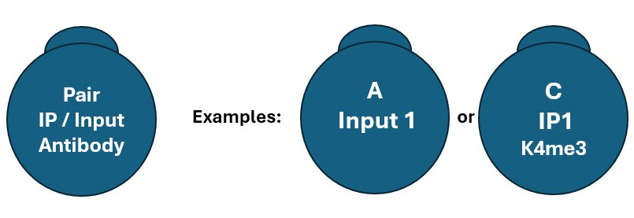

### Day 3

#### Binding and washes

- Add **20μl of washed magnetic beads** to each IP and incubate 4h at 4°C on a rotating wheel.
- Washes: Place the eppendorf tube on the magnetic rack for 3 min, remove supernatant, add 1 ml of the following cold buffers and incubate 10 min on rotating wheel each time at 4°C.
  1. Lysis buffer without protease inhibitor without CaCl2 - x2
  2. Lysis buffer NaCl
  3. LiCl Washbuffer - x2
  4. Tris-EDTA

#### Elution

- Resuspend the beads in 62.5μL of TES preheated at 65°C and incubate at 65°C for 10 min (vortex every 2 min or shake with the thermomixer).
- Place the tube on magnet and **SAVE the the supernatant** in a DNA LoBind Tube.
- Repeat the elution with again 62.5 µl of warm TES
- Pool the two elutions from the same IP into the same tube.

#### Cross-link reversal

- Adjust the volume of Input and IP to 500 µL with TES.
- Incubate the IPs and the Input at 65°C over-night to reverse the cross-link

### Day 4

#### DNA Purification

**Use DNA LoBind tubes for every steps**

- Treat the Input and IPs with:
  - RNAse A (20mg/ml): **2 μl for the IPs, 5 µl for the Inputs**, 120 min at 50°C
  - Proteinase K (20mg/ml): 10 μl, 120 min at 50°C
- Phenol extraction: to the Input and IPs
  - Add: 500μl phenol-chloroform
  - mix or vortex
  - centrifuge 3 min (top speed at room temperature)
  - recover the aqueous phase in a fresh DNA LoBind tube
  - Add: 500 μl chloroform
  - mix or vortex
  - centrifuge 3 min (top speed at room temperature)
  - recover the aqueous phase in a fresh DNA LoBind tube

#### DNA Precipitation

- To the IPs and Input:
  - Add 1/100th of glycogen
  - Add 1/10th of Sodium Acetate 3M
  - Vortex
  - Divide into two DNA LoBind tubes (approx 250µL / tube)
  - Add 2.5 volumes Ethanol 100% (i.e. approx 625µL 100% EtOH).
  - Vortex
  - Centrifuge 10 min 16000g, 4°C, carefully remove supernatant without disturbing the pellet
  - Wash with 400µl of 70% ethanol. Spin again 10 min and remove supernatant carefully
  - Air dry 10-20 min
  - Resuspend each pellet in 15μl of Tris-EDTA. Combine the two pellets of the same IP together. Combine the two pellets of the Input together. The total volume is 30µL.
- Quantify 2µL of the Input and IP sample with the Qubit dsDNA HS kit (follow the QuBit protocol)
- Store at -20°C. Evaluate the IP specificity by qPCR and/or proceed with the library preparation.